# Dependence of HNRNPH binding and cooperativity on rG4s

Mario Keller

Faculty of Biological Sciences, Goethe University Frankfurt

22 June 2023

```r
library(tidyverse)
library(knitr)
library(ggpubr)
library(ggsci)
library(ggbeeswarm)
library(ggrastr)
library(GenomicRanges)
library(BSgenome.Hsapiens.UCSC.hg38)
```

```r
myTheme <- theme_bw() +
    theme(axis.text = element_text(size = 14, colour="black"),
          axis.title = element_text(size=16, colour="black"),
          axis.ticks=element_line(color="black"),
          axis.ticks.length=unit(.15, "cm"),
          panel.border=element_rect(color="black", fill = NA),
          panel.background = element_blank(),
          plot.background = element_blank(),
          legend.text = element_text(size=12),
          legend.position = "none")
```

```r
projectDir <- "/Users/mariokeller/projects/HNRNPH_project/Tretow_et_al_2023"

iClipDir <- paste0(projectDir, "/4_iCLIP_analysis")
rG4Dir <- paste0(projectDir, "/5_rG4_analysis")
```

# 1 Background

In *Sequence_composition_of_binding_sites.Rmd* it became clear that HNRNPH binding is enriched at G-stretches. To elucidate a potential role of rG4s on the binding of HNRNPH and the cooperative regulation of CE events, binding site strength and the Hill coefficients of cooperatively regulated CE events are correlated with the presence and absence of rG4s.

# 2 Data

HNRNPH binding sites are loaded from a RDS-File created with *Binding_site_definition.R*.

Regulated and non-regulated CE minigenes are loaded from RDS-Files created with *Create_CE_minigenes.R*.

Predicted rG4s in regulated CE events and non-regulated CE events as well as around binding sites are loaded from RDS-Files created with *rG4_prediction.R*.

```r
bindingSites <- readRDS(paste0(iClipDir,
                               "/rds_files/HNRNPH_binding_sites.rds"))

regulatedMiniGenes <- readRDS(paste0(iClipDir, "/rds_files/regulatedMiniGenes.rds"))
nonRegulatedMiniGenes <- readRDS(paste0(iClipDir, "/rds_files/nonregulatedMiniGenes.rds"))

# The predicted rG4s are stored in RDS-Files
regulatedMiniGenesG4s <- readRDS(paste0(rG4Dir,
                                        "/rds_files/regulatedMiniGenesG4s.rds"))
nonRegulatedMiniGenesG4s <- readRDS(paste0(rG4Dir,
                                           "/rds_files/nonRegulatedMiniGenesG4s.rds"))
bindingSitesG4s <- readRDS(paste0(rG4Dir,
                                  "/rds_files/bindingSitesG4s.rds"))
```

The introns (between C1 and A as well as between A and C2) are added to each GRanges object.

```r
regulatedMiniGenes <- regulatedMiniGenes %>% lapply(., function(gr){
    tmp <- gaps(gr, start=NA, end=NA)
    mcols(tmp) <- mcols(gr)[1:2,]
    if(strand(tmp) %>% unique == "+"){
    tmp$exon <- c("I1", "I2")
    } else {
    tmp$exon <- c("I2", "I1")
    }
    gr <- c(gr, tmp)
    return(gr)
}) %>% as(., "GRangesList")

nonRegulatedMiniGenes <- nonRegulatedMiniGenes %>% lapply(., function(gr){
  tmp <- gaps(gr, start=NA, end=NA)
  mcols(tmp) <- mcols(gr)[1:2,]
  if(strand(tmp) %>% unique == "+"){
    tmp$exon <- c("I1", "I2")
  } else {
    tmp$exon <- c("I2", "I1")
  }
  gr <- c(gr, tmp)
  return(gr)
}) %>% as(., "GRangesList")
```

rG4s located in CE events are loaded as a list, where each list entry is a GRanges object comprising the predicted rG4s of a single CE event. The list is resolved using unlist(), followed by removeal of duplcated rG4s. Duplicates may arise when there are overlapping CE events due to overlapping genes on the same strand (e.g if there is gene readthrough).

```r
regulatedMiniGenesG4s <- regulatedMiniGenesG4s %>%
    as(., "GRangesList") %>%
    unlist
regulatedMiniGenesG4s <- regulatedMiniGenesG4s[!duplicated(regulatedMiniGenesG4s)]

nonRegulatedMiniGenesG4s <- nonRegulatedMiniGenesG4s %>%
    as(., "GRangesList") %>%
    unlist
nonRegulatedMiniGenesG4s <- nonRegulatedMiniGenesG4s[!duplicated(nonRegulatedMiniGenesG4s)]
```

# 3 The effect of G-stretches and rG4 propensity on binding strength

From the analyses in *Sequence_composition_of_binding_sites.Rmd* it became clear that there is an enrichment of G-triplats (GGG) in and around strong binding sites. To obtain insights on the impact of G-stretches and their location in predicted rG4s on binding, the 468,452 binding sites were assigned to one of the following four groups:

1. contains no G-triplet and does not overlap a predicted rG4 (-/-)
2. contains no G-triplet and overlaps a predicted rG4 (-/+)
3. contains a G-triplet and does not overlap a predicted rG4 (+/-)
4. contains a G-triplet and overlaps a predicted rG4 (+/+)

For each of the four groups the PureCLIP score distribution was examined.

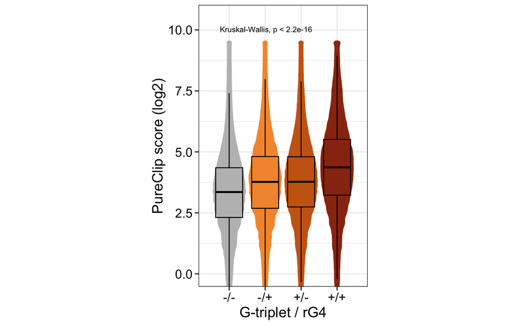

```r
# Get the sequence of the binding sites
bindingSitesRSS <- RNAStringSet(getSeq(Hsapiens, bindingSites))

# Initialize the group information
bindingSites$group <- "-/-"

# Adjust the group based on the the presence of 3 Gs and overlap with a
#   predicted rG4
bindingSites$group[vmatchPattern("GGG", bindingSitesRSS) %>% lengths > 0] <- "+/-"
bindingSites$group[countOverlaps(bindingSites, bindingSitesG4s) > 0 & bindingSites$group == "+/-"] <- "+/+"
bindingSites$group[countOverlaps(bindingSites, bindingSitesG4s) > 0 & bindingSites$group == "-/-"] <- "-/+"

# The four PureCLIP score distributions are shown as a combination
#   of beeswarm plot and boxplot
data.frame(group=bindingSites$group, score=bindingSites$score) %>%
    mutate(group=factor(group, levels=c("-/-", "-/+", "+/-", "+/+"))) %>%
    ggplot(., aes(x=group, y=log2(score), col=group, fill=group))+
        ggrastr::rasterise(geom_quasirandom(dodge.width = 0.9), dpi=300) +
        geom_boxplot(alpha=.5, outlier.size = -1, col="black", position = position_dodge(width = 0.9)) +
        scale_color_manual(values=c("-/-" = "grey", "-/+" = "#F49738", "+/-" = "#CB6615", "+/+" = "#9A3415")) +
        scale_fill_manual(values=c("-/-" = "grey", "-/+" = "#F49738", "+/-" = "#CB6615", "+/+" = "#9A3415")) +
        stat_compare_means(method="kruskal.test", vjust=-2, hjust=0.1, size=3) +
        coord_cartesian(ylim=c(0,10.5)) +
        labs(y="PureClip score (log2)", x="G-triplet / rG4") +
        myTheme +
        theme(legend.position = "none", aspect.ratio = 1/.6)
```

Here is the underlying data.frame as a table:

```r
bindingSites %>%
    as.data.frame %>%
    dplyr::count(group) %>%
    kable(., "html") %>%
    kableExtra::kable_styling("striped") %>%
    kableExtra::scroll_box(width = "94%")
```

| group | n |
| --- | --- |
| -/- | 242931 |
| -/+ | 42164 |
| +/- | 104200 |
| +/+ | 79157 |

One can see that binding sites are stronger if located on G-triplets in predicted rG4s.

# 4 rG4s overlapping CE events

In the final analysis it was of interest to check whether the three sets (Coop-Enh, Cooop-Rep and nonReg) show differences in terms of the presence/absence of rG4s in the AEs and intron regions that showed strong signal differences in the HNRNPH iCLIP RNAmaps. The intronic regions comprise the 3’ end of the upstream (I1) intron and the the 5’ and 3’ end of the downstream intron (I2). The three intronic regions are combined as the “intronic” region. At maximum I went 300nt in the intronic regions.

```r
# Create a vector containing the Hill categories
hillCat <- regulatedMiniGenes %>% sapply(., function(gr){gr$hillCat[1]})

# Create GRanges objects for the alternative exons (AE), upstream intron
#   end (I1end) as well a the start (I2start) and end (I2end) of the downstream
#   exon for the cooperatively regulated CE events and non-regulated CE events

# Coop-Enh
AE_CoopEnh <- endoapply(regulatedMiniGenes[hillCat == "Coop-Enh"],
                         function(gr){gr[gr$exon=="A"]}) %>% unlist
I1end_CoopEnh <- endoapply(regulatedMiniGenes[hillCat == "Coop-Enh"],
                           function(gr){gr[gr$exon=="I1"] %>%
                                   resize(., min(width(.), 300), fix="end")}) %>% unlist
I2start_CoopEnh <- endoapply(regulatedMiniGenes[hillCat == "Coop-Enh"],
                           function(gr){gr[gr$exon=="I2"] %>%
                                   resize(., min(width(.), 300), fix="start")}) %>% unlist
I2end_CoopEnh <- endoapply(regulatedMiniGenes[hillCat == "Coop-Enh"],
                           function(gr){gr[gr$exon=="I2"] %>%
                                   resize(., min(width(.), 300), fix="end")}) %>% unlist

# Coop-Rep
AE_CoopRep <- endoapply(regulatedMiniGenes[hillCat == "Coop-Rep"],
                         function(gr){gr[gr$exon=="A"]}) %>% unlist
I1end_CoopRep <- endoapply(regulatedMiniGenes[hillCat == "Coop-Rep"],
                           function(gr){gr[gr$exon=="I1"] %>%
                                   resize(., min(width(.), 300), fix="end")}) %>% unlist
I2start_CoopRep <- endoapply(regulatedMiniGenes[hillCat == "Coop-Rep"],
                           function(gr){gr[gr$exon=="I2"] %>%
                                   resize(., min(width(.), 300), fix="start")}) %>% unlist
I2end_CoopRep <- endoapply(regulatedMiniGenes[hillCat == "Coop-Rep"],
                           function(gr){gr[gr$exon=="I2"] %>%
                                   resize(., min(width(.), 300), fix="end")}) %>% unlist

# nonReg
AE_nonReg <- endoapply(nonRegulatedMiniGenes,
                        function(gr){gr[gr$exon=="A"]}) %>% unlist
I1end_nonReg <- endoapply(nonRegulatedMiniGenes,
                           function(gr){gr[gr$exon=="I1"] %>%
                                   resize(., min(width(.), 300), fix="end")}) %>% unlist
I2start_nonReg <- endoapply(nonRegulatedMiniGenes,
                           function(gr){gr[gr$exon=="I2"] %>%
                                   resize(., min(width(.), 300), fix="start")}) %>% unlist
I2end_nonReg <- endoapply(nonRegulatedMiniGenes,
                           function(gr){gr[gr$exon=="I2"] %>%
                                   resize(., min(width(.), 300), fix="end")}) %>% unlist
```

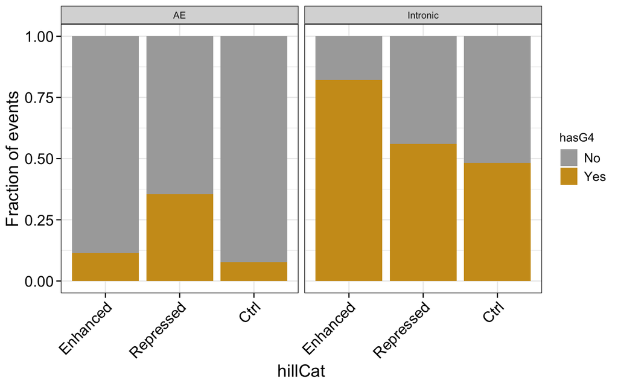

```r
# Count the number of overlapping predicted rG4s for each alternative exon (AE)
#   and the three intronic regions. Counts of the intronc regions are combined.
G4freqDf <- rbind(
    data.frame(hillCat = "Coop-Enh",
               facet = "AE",
               rG4freq = countOverlaps(AE_CoopEnh, regulatedMiniGenesG4s),
               nH = regulatedMiniGenes[hillCat == "Coop-Enh"] %>%
                   sapply(., function(gr){gr$nH[1]})),
    data.frame(hillCat = "Coop-Rep",
               facet = "AE",
               rG4freq = countOverlaps(AE_CoopRep, regulatedMiniGenesG4s),
               nH = regulatedMiniGenes[hillCat == "Coop-Rep"] %>%
                   sapply(., function(gr){gr$nH[1]})),
    data.frame(hillCat = "nonReg",
               facet = "AE",
               rG4freq = countOverlaps(AE_nonReg, nonRegulatedMiniGenesG4s),
               nH = NA),
    data.frame(hillCat = "Coop-Enh",
               facet = "Intronic",
               rG4freq = countOverlaps(I1end_CoopEnh, regulatedMiniGenesG4s) +
                   countOverlaps(I2start_CoopEnh, regulatedMiniGenesG4s) +
                   countOverlaps(I2end_CoopEnh, regulatedMiniGenesG4s),
               nH = regulatedMiniGenes[hillCat == "Coop-Enh"] %>%
                   sapply(., function(gr){gr$nH[1]})),
    data.frame(hillCat = "Coop-Rep",
               facet = "Intronic",
               rG4freq = countOverlaps(I1end_CoopRep, regulatedMiniGenesG4s) +
                   countOverlaps(I2start_CoopRep, regulatedMiniGenesG4s) +
                   countOverlaps(I2end_CoopRep, regulatedMiniGenesG4s),
               nH = regulatedMiniGenes[hillCat == "Coop-Rep"] %>%
                   sapply(., function(gr){gr$nH[1]})),
    data.frame(hillCat = "nonReg",
               facet = "Intronic",
               rG4freq = countOverlaps(I1end_nonReg, nonRegulatedMiniGenesG4s) +
                   countOverlaps(I2start_nonReg, nonRegulatedMiniGenesG4s) +
                   countOverlaps(I2end_nonReg, nonRegulatedMiniGenesG4s),
               nH = NA)
)

# Combine counts >2
G4freqDf$rG4freq[G4freqDf$rG4freq > 2] <- ">2"
G4freqDf$rG4freq <- factor(G4freqDf$rG4freq, levels=c("0", "1", "2", ">2"))

# Just check if there is an overlapping G4
G4freqDf <- G4freqDf %>%
    mutate(hasG4 = ifelse(rG4freq == "0", "No", "Yes"))


# Create a stacked barchart showing the fraction of CE events with a certain
#   number of overlapping rG4s
G4freqDf %>%
    mutate(hillCat = case_when(hillCat == "Coop-Enh" ~ "Enhanced",
                               hillCat == "Coop-Rep" ~ "Repressed",
                               TRUE ~ "Ctrl")) %>%
    mutate(hillCat = factor(hillCat, levels=c("Enhanced", "Repressed", "Ctrl"))) %>%
    ggplot(., aes(x=hillCat, fill=hasG4)) +
        geom_bar(position="fill") +
        scale_fill_manual(values=c("No"="darkgrey", "Yes"="goldenrod3")) +
        facet_wrap(~facet, ncol=2) +
        labs(y="Fraction of events") +
        myTheme +
        theme(legend.position = "right",
              axis.text.x = element_text(angle=45, vjust = 1, hjust = 1))
```

Here is the underlying data.frame as a table:

```r
G4freqDf %>%
    dplyr::count(hillCat, facet, rG4freq) %>%
    group_by(hillCat, facet) %>%
    mutate(fraction = n/sum(n)) %>%
    ungroup %>%
    kable(., "html") %>%
    kableExtra::kable_styling("striped") %>%
    kableExtra::scroll_box(height="300px", width = "94%")
```

| hillCat | facet | rG4freq | n | fraction |
| --- | --- | --- | --- | --- |
| Coop-Enh | AE | 0 | 69 | 0.8846154 |
| Coop-Enh | AE | 1 | 7 | 0.0897436 |
| Coop-Enh | AE | 2 | 1 | 0.0128205 |
| Coop-Enh | AE | >2 | 1 | 0.0128205 |
| Coop-Enh | Intronic | 0 | 14 | 0.1794872 |
| Coop-Enh | Intronic | 1 | 24 | 0.3076923 |
| Coop-Enh | Intronic | 2 | 12 | 0.1538462 |
| Coop-Enh | Intronic | >2 | 28 | 0.3589744 |
| Coop-Rep | AE | 0 | 144 | 0.6457399 |
| Coop-Rep | AE | 1 | 58 | 0.2600897 |
| Coop-Rep | AE | 2 | 13 | 0.0582960 |
| Coop-Rep | AE | >2 | 8 | 0.0358744 |
| Coop-Rep | Intronic | 0 | 98 | 0.4394619 |
| Coop-Rep | Intronic | 1 | 40 | 0.1793722 |
| Coop-Rep | Intronic | 2 | 35 | 0.1569507 |
| Coop-Rep | Intronic | >2 | 50 | 0.2242152 |
| nonReg | AE | 0 | 1062 | 0.9226759 |
| nonReg | AE | 1 | 82 | 0.0712424 |
| nonReg | AE | 2 | 7 | 0.0060817 |
| nonReg | Intronic | 0 | 596 | 0.5178106 |
| nonReg | Intronic | 1 | 234 | 0.2033015 |
| nonReg | Intronic | 2 | 152 | 0.1320591 |
| nonReg | Intronic | >2 | 169 | 0.1468288 |

The fraction of CE events with at least one predicted rG4 overlapping the cassette/alternative exon is highest for the cooperatively repressed events, while there are nearly no non-regulated CE events with a predicted rG4 overlapping the cassette/alternative exon.

The fraction of CE events with at least one predicted rG4 overlapping the intronic regions is highest for the cooperatively enhanced events and lowest for the non-regulated events. There is also a substantial fraction of enhanced CE events with more than two predicted rG4s in the intronic regions.

Also statistical tests are performed, to check if the differences in the proportions are significant. The “pairwise.prop.test()” function is used, which automatically corrects for multiple testing using the “BH” (default would be “holm”) method. Tests are performed and corrected independently for “AE” and “intronic”.

Here is the result for the left plot (AE):

```r
test_mat <- G4freqDf %>%
    filter(facet=="AE") %>%
    group_by(hillCat) %>%
    dplyr::summarize(success=sum(hasG4 == "Yes"), trials=n()) %>%
    tibble::column_to_rownames(., var="hillCat") %>%
    as.matrix
pairwise.prop.test(test_mat[,1], test_mat[,2], p.adjust.method = "BH")
```

```
##
##  Pairwise comparisons using Pairwise comparison of proportions
##
## data:  test_mat[, 1] out of test_mat[, 2]
##
##          Coop-Enh Coop-Rep
## Coop-Rep 0.00018  -
## nonReg   0.32467  < 2e-16
##
## P value adjustment method: BH
```

Here is the result for the right plot (Intronic):

```r
test_mat <- G4freqDf %>%
    filter(facet=="Intronic") %>%
    group_by(hillCat) %>%
    dplyr::summarize(success=sum(hasG4 == "Yes"), trials=n()) %>%
    tibble::column_to_rownames(., var="hillCat") %>%
    as.matrix
pairwise.prop.test(test_mat[,1], test_mat[,2], p.adjust.method = "BH")
```

```
##
##  Pairwise comparisons using Pairwise comparison of proportions
##
## data:  test_mat[, 1] out of test_mat[, 2]
##
##          Coop-Enh Coop-Rep
## Coop-Rep 0.00012  -
## nonReg   4.4e-08  0.03858
##
## P value adjustment method: BH
```

What is also visible, is that the fraction of inronic regions with an overlapping rG4 is much higher than the fraction of alternative exons with an overlapping rG4. However, the alternative exons are much shorter than the up to 3x300 nt intronic regions.

To account for this difference, the number of overlapping predicted rG4s per nucleotide is computed. This is done by dividing the number of events with $\ge$ overlapping rG4 by the summed up length of alternative exons / intronic regions.

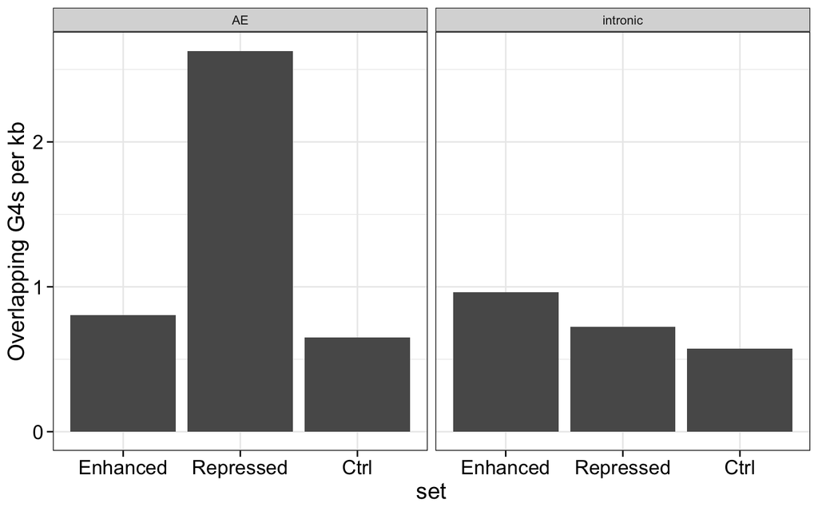

```r
nG4s <- countOverlaps(AE_CoopEnh, regulatedMiniGenesG4s[!duplicated(regulatedMiniGenesG4s)])
normalized_G4s_CoopEnh_AE <- sum(nG4s >0) / sum(width(AE_CoopEnh))

nG4s <- countOverlaps(AE_CoopRep, regulatedMiniGenesG4s[!duplicated(regulatedMiniGenesG4s)])
normalized_G4s_CoopRep_AE <- sum(nG4s >0) / sum(width(AE_CoopRep))

nG4s <- countOverlaps(AE_nonReg, nonRegulatedMiniGenesG4s[!duplicated(nonRegulatedMiniGenesG4s)])
normalized_G4s_nonReg_AE <- sum(nG4s >0) / sum(width(AE_nonReg))


I1end_nG4s <- countOverlaps(I1end_CoopEnh, regulatedMiniGenesG4s[!duplicated(regulatedMiniGenesG4s)])
I2start_nG4s <- countOverlaps(I2start_CoopEnh, regulatedMiniGenesG4s[!duplicated(regulatedMiniGenesG4s)])
I2end_nG4s <- countOverlaps(I2end_CoopEnh, regulatedMiniGenesG4s[!duplicated(regulatedMiniGenesG4s)])

normalized_G4s_CoopEnh_intronic <- sum((I1end_nG4s + I2start_nG4s + I2end_nG4s) >0) / sum(width(c(I1end_CoopEnh, I2start_CoopEnh, I2end_CoopEnh)))


I1end_nG4s <- countOverlaps(I1end_CoopRep, regulatedMiniGenesG4s[!duplicated(regulatedMiniGenesG4s)])
I2start_nG4s <- countOverlaps(I2start_CoopRep, regulatedMiniGenesG4s[!duplicated(regulatedMiniGenesG4s)])
I2end_nG4s <- countOverlaps(I2end_CoopRep, regulatedMiniGenesG4s[!duplicated(regulatedMiniGenesG4s)])

normalized_G4s_CoopRep_intronic <- sum((I1end_nG4s + I2start_nG4s + I2end_nG4s) >0) / sum(width(c(I1end_CoopRep, I2start_CoopRep, I2end_CoopRep)))


I1end_nG4s <- countOverlaps(I1end_nonReg, nonRegulatedMiniGenesG4s[!duplicated(nonRegulatedMiniGenesG4s)])
I2start_nG4s <- countOverlaps(I2start_nonReg, nonRegulatedMiniGenesG4s[!duplicated(nonRegulatedMiniGenesG4s)])
I2end_nG4s <- countOverlaps(I2end_nonReg, nonRegulatedMiniGenesG4s[!duplicated(nonRegulatedMiniGenesG4s)])

normalized_G4s_nonReg_intronic <- sum((I1end_nG4s + I2start_nG4s + I2end_nG4s) >0) / sum(width(c(I1end_nonReg, I2start_nonReg, I2end_nonReg)))

data.frame(
    set=c("Enhanced", "Enhanced",
          "Repressed", "Repressed",
          "Ctrl", "Ctrl"),
    region=c("AE", "intronic",
             "AE", "intronic",
             "AE", "intronic"),
    norm_G4_overlap=c(normalized_G4s_CoopEnh_AE, normalized_G4s_CoopEnh_intronic,
                      normalized_G4s_CoopRep_AE, normalized_G4s_CoopRep_intronic,
                      normalized_G4s_nonReg_AE, normalized_G4s_nonReg_intronic) * 1000
) %>%
    mutate(set=factor(set, levels=c("Enhanced", "Repressed", "Ctrl"))) %>%
    ggplot(., aes(x=set, y=norm_G4_overlap)) +
    geom_col(position="dodge") +
    labs(y="Overlapping G4s per kb") +
    facet_wrap(~region) +
    myTheme +
    theme(legend.position = "right")
```

# 5 Dependence of Hill coefficient on the presence of rG4s

After observing a high density of predicted rG4s overlapping the alternative exon of cooperatively repressed CE events and in the intronic regions of cooperatively enhanced events, it was of interest whether the degree of cooperativity depends on the presence of predicted rG4s.

To answer this question, repressed and enhanced CE events were each put into five groups (0-20%, 20-40%, 40-60%, 60-80% and 80-100%) based on the fitted Hill coefficient (nH). Afterwards the five groups of repressed CE events were compared for the presence of predicted rG4s overlapping the alternative exon and the five groups of enhanced CE events for the presence of predicted rG4s in the intron regions.

Here is the plot and the underlying data.frame for the repressed CE events:

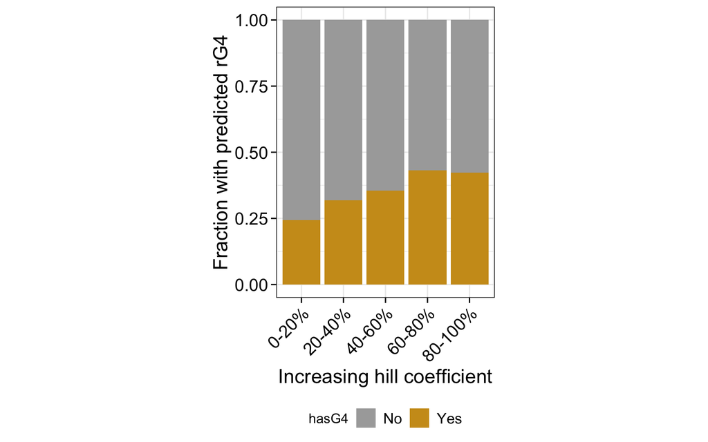

```r
plotDf <- G4freqDf %>% dplyr::filter(hillCat == "Coop-Rep",
                           facet=="AE")
plotDf$nHquantile <- cut(abs(plotDf$nH),
                         breaks=abs(plotDf$nH) %>% quantile(., seq(0,1,0.2)),
                         include.lowest = TRUE,
                         labels=c("0-20%","20-40%","40-60%","60-80%","80-100%"))

plotDf %>%
    ggplot(., aes(x=nHquantile, fill=hasG4)) +
    scale_fill_manual(values=c("No"="darkgrey", "Yes"="goldenrod3")) +
    geom_bar(position="fill") +
    labs(x="Increasing hill coefficient", y="Fraction with predicted rG4") +
    myTheme +
    theme(legend.position = "bottom",
          aspect.ratio=1/.75,
          axis.text.x = element_text(angle=45, vjust = 1, hjust = 1))
```

```r
plotDf %>% dplyr::count(nHquantile, rG4freq) %>%
    group_by(nHquantile) %>%
    mutate(fraction = n/sum(n)) %>%
    ungroup %>%
    kable(., "html") %>%
    kableExtra::kable_styling("striped") %>%
    kableExtra::scroll_box(height="300px", width = "94%")
```

| nHquantile | rG4freq | n | fraction |
| --- | --- | --- | --- |
| 0-20% | 0 | 34 | 0.7555556 |
| 0-20% | 1 | 9 | 0.2000000 |
| 0-20% | 2 | 1 | 0.0222222 |
| 0-20% | >2 | 1 | 0.0222222 |
| 20-40% | 0 | 30 | 0.6818182 |
| 20-40% | 1 | 12 | 0.2727273 |
| 20-40% | 2 | 1 | 0.0227273 |
| 20-40% | >2 | 1 | 0.0227273 |
| 40-60% | 0 | 29 | 0.6444444 |
| 40-60% | 1 | 9 | 0.2000000 |
| 40-60% | 2 | 5 | 0.1111111 |
| 40-60% | >2 | 2 | 0.0444444 |
| 60-80% | 0 | 25 | 0.5681818 |
| 60-80% | 1 | 16 | 0.3636364 |
| 60-80% | 2 | 2 | 0.0454545 |
| 60-80% | >2 | 1 | 0.0227273 |
| 80-100% | 0 | 26 | 0.5777778 |
| 80-100% | 1 | 12 | 0.2666667 |
| 80-100% | 2 | 4 | 0.0888889 |
| 80-100% | >2 | 3 | 0.0666667 |

Also a statistical test is performed to check if the differences in the proportions are significant. The “prop.test()” function is applied on the lowest and highest quantile.

Here is the result:

```r
test_mat <- plotDf %>%
    group_by(nHquantile) %>%
    dplyr::summarize(success=sum(hasG4 == "Yes"), trials=n()) %>%
    tibble::column_to_rownames(., var="nHquantile") %>%
    as.matrix
prop.test(test_mat[c(1,5),1], test_mat[c(1,5),2])
```

```
##
##  2-sample test for equality of proportions with continuity correction
##
## data:  test_mat[c(1, 5), 1] out of test_mat[c(1, 5), 2]
## X-squared = 2.45, df = 1, p-value = 0.1175
## alternative hypothesis: two.sided
## 95 percent confidence interval:
##  -0.39128864  0.03573309
## sample estimates:
##    prop 1    prop 2
## 0.2444444 0.4222222
```

To check for the strength of the relationship, I increase the number of groups by going in 10% steps and plotting the 10 groups against the fraction of events with $\ge$ 1 overlapping rG4.

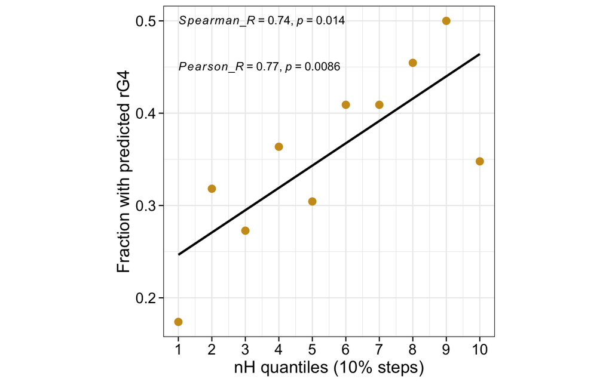

```r
plotDf$new_nHquantile <- cut(abs(plotDf$nH), breaks=abs(plotDf$nH) %>% quantile(., seq(0,1,0.1)), include.lowest = TRUE, labels=c(1, 2, 3, 4, 5, 6, 7, 8, 9, 10)) %>% as.character %>% as.integer()

plotDf %>% dplyr::select(hasG4, new_nHquantile) %>%
    dplyr::group_by(new_nHquantile) %>%
    dplyr::summarize(fraction=sum(hasG4 == "Yes")/dplyr::n()) %>%
    ggplot(., aes(x=new_nHquantile, y=fraction)) +
    geom_point(size=3, color="goldenrod3") +
    geom_smooth(method="lm", se=FALSE, color="black") +
    scale_x_continuous(breaks=1:10) +
    stat_cor(method="spearman", cor.coef.name="Spearman_R", label.y=0.5) +
    stat_cor(method="pearson", cor.coef.name="Pearson_R", label.y=0.45) +
    labs(x="nH quantiles (10% steps)",
         y="Fraction with predicted rG4") +
    myTheme +
    theme(aspect.ratio=1)
```

Here is the plot and the underlying data.frame for the enhanced CE events:

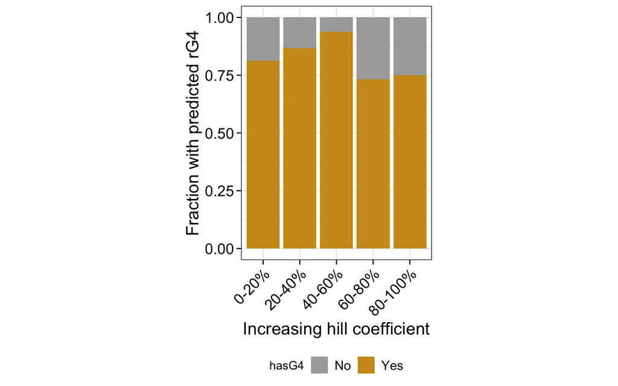

```r
plotDf <- G4freqDf %>% dplyr::filter(hillCat == "Coop-Enh",
                           facet=="Intronic")
plotDf$nHquantile <- cut(abs(plotDf$nH),
                         breaks=abs(plotDf$nH) %>% quantile(., seq(0,1,0.2)),
                         include.lowest = TRUE,
                         labels=c("0-20%","20-40%","40-60%","60-80%","80-100%"))

plotDf %>%
    ggplot(., aes(x=nHquantile, fill=hasG4)) +
    scale_fill_manual(values=c("No"="darkgrey", "Yes"="goldenrod3")) +
    geom_bar(position="fill") +
    labs(x="Increasing hill coefficient", y="Fraction with predicted rG4") +
    myTheme +
    theme(legend.position = "bottom",
          aspect.ratio=1/.75,
          axis.text.x = element_text(angle=45, vjust = 1, hjust = 1))
```

```r
plotDf %>% dplyr::count(nHquantile, rG4freq) %>%
    group_by(nHquantile) %>%
    mutate(fraction = n/sum(n)) %>%
    ungroup %>%
    kable(., "html") %>%
    kableExtra::kable_styling("striped") %>%
    kableExtra::scroll_box(height="300px", width = "94%")
```

| nHquantile | rG4freq | n | fraction |
| --- | --- | --- | --- |
| 0-20% | 0 | 3 | 0.1875000 |
| 0-20% | 1 | 5 | 0.3125000 |
| 0-20% | >2 | 8 | 0.5000000 |
| 20-40% | 0 | 2 | 0.1333333 |
| 20-40% | 1 | 5 | 0.3333333 |
| 20-40% | 2 | 2 | 0.1333333 |
| 20-40% | >2 | 6 | 0.4000000 |
| 40-60% | 0 | 1 | 0.0625000 |
| 40-60% | 1 | 7 | 0.4375000 |
| 40-60% | 2 | 4 | 0.2500000 |
| 40-60% | >2 | 4 | 0.2500000 |
| 60-80% | 0 | 4 | 0.2666667 |
| 60-80% | 1 | 5 | 0.3333333 |
| 60-80% | 2 | 3 | 0.2000000 |
| 60-80% | >2 | 3 | 0.2000000 |
| 80-100% | 0 | 4 | 0.2500000 |
| 80-100% | 1 | 2 | 0.1250000 |
| 80-100% | 2 | 3 | 0.1875000 |
| 80-100% | >2 | 7 | 0.4375000 |

For the cooperatively repressed CE events the fraction of events with at least one predicted rG4 overlapping the cassette/alternative exon increases with the degree of cooperativity suggesting a potential link between cooperativity and rG4 formation.

Again a statistical test on the lowest and highest quantiles was performed. Here is the result:

```r
test_mat <- plotDf %>%
    group_by(nHquantile) %>%
    dplyr::summarize(success=sum(hasG4 == "Yes"), trials=n()) %>%
    tibble::column_to_rownames(., var="nHquantile") %>%
    as.matrix
prop.test(test_mat[c(1,5),1], test_mat[c(1,5),2])
```

```
##
##  2-sample test for equality of proportions with continuity correction
##
## data:  test_mat[c(1, 5), 1] out of test_mat[c(1, 5), 2]
## X-squared = 0, df = 1, p-value = 1
## alternative hypothesis: two.sided
## 95 percent confidence interval:
##  -0.2856457  0.4106457
## sample estimates:
## prop 1 prop 2
## 0.8125 0.7500
```